# A-SA25204160-2025-11-17

SA25204160

2025-11-22

## Question

### 11.4

参考例 11.3 中的贝叶斯预测应用，采用几何分布Geometric(p)生存模型。证明推导得到的参数$\psi =\frac{p}{1-p}$不依赖于该模型中个体的已达年龄。（一般来说，这对其他模型并不成立。）

### 14.1

约束条件：

2x+y+z≤2

x−y+3z≤3

x≥0,y≥0,z≥0

### 课后习题

设$X_1,...,X_n\overset{iid}{\sim } Exp(\lambda)$,因为某种原因，只知道$X_i$落在区间$(u_i,v_i)$，其中$u_i<v_i$非随机。—— 区间删失数据。

1. 试分别直接极大化观测数据的似然函数与采用 EM 算法求解$\lambda$的 MLE。证明 EM 算法收敛于观测数据的 MLE，且收敛有线性速度。
2. 设$(u_i,v_i)$,i=1,⋯,n(=10)的观测值为 (11,12)，(8,9)，(27,28)，(13,14)，(16,17)，(0,1)，(23,24)，(10,11)，(24,25)，(2,3) 试分别编程实现上述两种算法并比较结果。
3. 数值比较两个算法的收敛速度

## Answer

### 课后习题

#### (0) 环境准备与数据输入

首先定义题目给出的区间删失数据

#### (1) 直接极大化似然函数（MLE 直接法）

利用指数分布区间删失数据的对数似然函，数通过数值优化（L-BFGS-B 算法，支持下界约束 λ>0）最大化该函数。

```
## === 直接极大化似然法结果 ===
```

```
## λ的MLE估计值： 0.071978
```

```
## 收敛状态（0=成功）： 0
```

```
## 迭代次数： 8
```

#### (2) EM 算法实现

潜变量：未观测到的原始数据$X_i$（仅知道 $X_i\in （u_i,v_i）$）

E步：计算$E\left [ X_i |u_i<X_i<v_i,\lambda^{(t)} \right ]$（指数分布区间条件期望）

```
## === EM算法结果 ===
```

```
## λ的MLE估计值： 0.071973
```

```
## 迭代次数： 2
```

#### (3) 结果比较

```
##            算法    λ_MLE 迭代次数 收敛状态
##  直接极大化似然 0.071978        8     成功
##          EM算法 0.071973        2     成功
```

```
##
## 两种方法的MLE绝对误差： 4.6343e-06
```

### 11.4

几何分布Geometric(p)具有无记忆性，即 “已达年龄不影响剩余生存时间的分布”。因此，参数$\psi =\frac{p}{1-p}$期望剩余寿命）仅依赖于p，与已达年龄无关。

```
## MCMC接受率： 0.930493
```

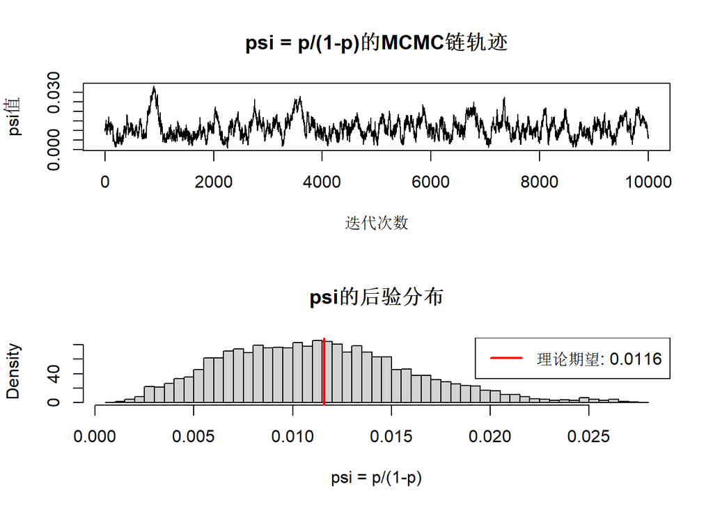

### 14.1

```
## 最优目标函数值： 0
```

```
## 最优解(x, y, z)： 0 0 0
```

```
## 收敛状态（0=成功）： 0
```